# serie de tiempo de exportaciones

Aurelio Reyna Hernandez

2022-12-13

#Exportaciones netas

#### librerias del proyecto

```r
library(lubridate)
library(tidyverse)
library(tseries)
library(quantmod)
library(astsa)
library(forecast)
library(quantmod)
library(mFilter)
library(nortest)
```

### cargamos los datos la serie

```r
exportaciones <- read.csv("serie limpia.csv")

exportaciones <-exportaciones %>% select(Exportaciones..totales)

head(exportaciones, 10)
```

```
##    Exportaciones..totales
## 1                 3491025
## 2                 3824112
## 3                 4454157
## 4                 4131085
## 5                 4125457
## 6                 4789999
## 7                 4151908
## 8                 4219402
## 9                 4446892
## 10                4923708
```

### convertimos en objeto serie de tiempo y graficamos

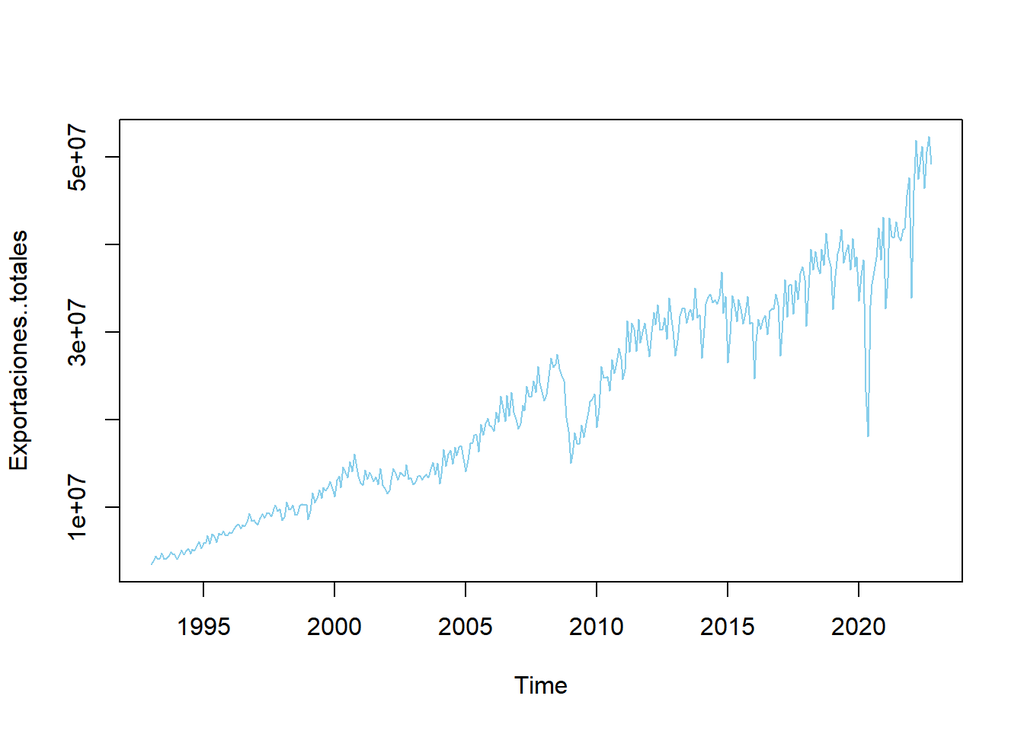

```r
time_exportaciones <- ts(exportaciones, start = c(1993, 1), frequency = 12)

plot(time_exportaciones, col="skyblue")
```

R:La prueba grafica nos dice que la serie no es estacionaria debido al hecho de que la serie pose una tendencia y se asume que su media y desviacion no es la misma a lo largo de la serie.

### decomposicion de la serie en en el factor ciclico y el factor tendencial

#### filtro hodick-prescott

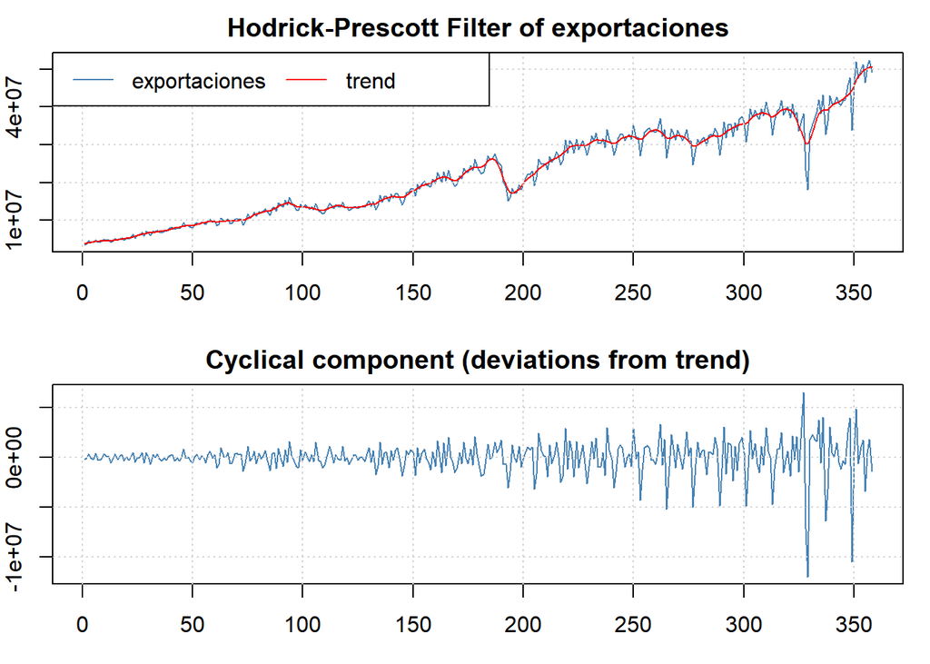

```r
hp.filtered <- hpfilter(exportaciones, freq=12)
plot(hp.filtered)
```

la tendencia de la serie es a la alza y la tryctoria del componente ciclico es divergente por lo que parece ser que el modelo optimo por el momento va a ser un modelo arima como primer paso vamos a correr la prueba de dickye-fuller

#### planteamiento de hipotesis

$$\left\{
\begin{array}{ll}
H_0: & > 0.5 & no & estacionaria & (raiz &
unitaria)\\
H_1: & < 0.5 & es & estacionaria\\
\end{array}
\right.$$

pero antes debemos usar un logaritmo para observar si la serie se vuelve estacionaria

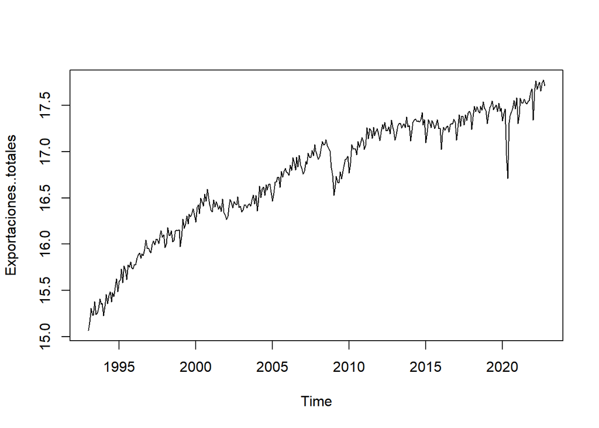

```r
serlog <- log(time_exportaciones)
plot(serlog)
```

### prueba de dickey-fuller para la serie con logaritmo

```r
adf.test(serlog, alternative = "stationary")
```

```
##
##  Augmented Dickey-Fuller Test
##
## data:  serlog
## Dickey-Fuller = -3.1705, Lag order = 7, p-value = 0.09315
## alternative hypothesis: stationary
```

```r
adf.test(time_exportaciones, alternative = "stationary")
```

```
##
##  Augmented Dickey-Fuller Test
##
## data:  time_exportaciones
## Dickey-Fuller = -3.411, Lag order = 7, p-value = 0.05248
## alternative hypothesis: stationary
```

La prueba Dickey-Fuller en la serie logaritmica(linealizada) de las exportaciones nos indica que la serie no es estacionaria ya que el p-value(0.09315) > 0.05.

sin embargo la prueba estadistica en la serie no logaritmica es muy proxima ya que el p-value(0.05248)es muy cercano al 0.5 por lo que se podria decir que la serie solo podria requerir una diferencia paravolverse estacionaria.

conclusion: no existen evidencias suficientes para rechazar la hipotesis nula:la serie no es estacionaria y cuenta con raices unitarias.

# inducimos estacionariedad

### primera diferencia y grafica en la serie logaritmica

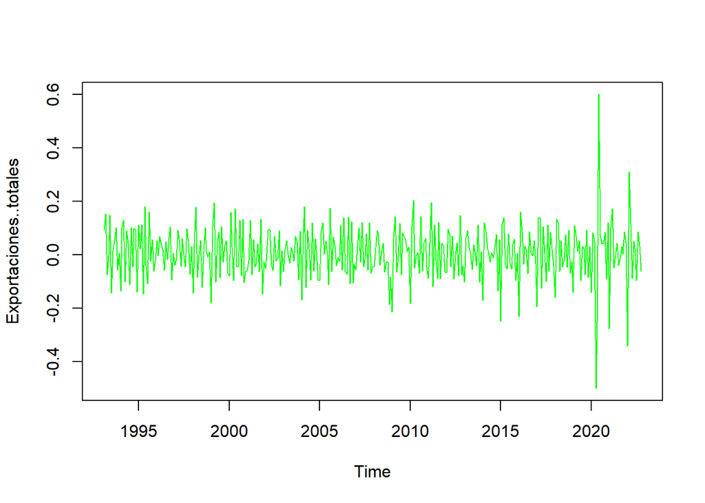

```r
#diferencia en la serie con logaritmo
diflog1 <- diff(serlog)
#diferencia en la serie sin logaritmo
dif1 <- diff(time_exportaciones)

plot(diflog1, col="green")
```

### grafica de la diferencia en la serie exportaciones

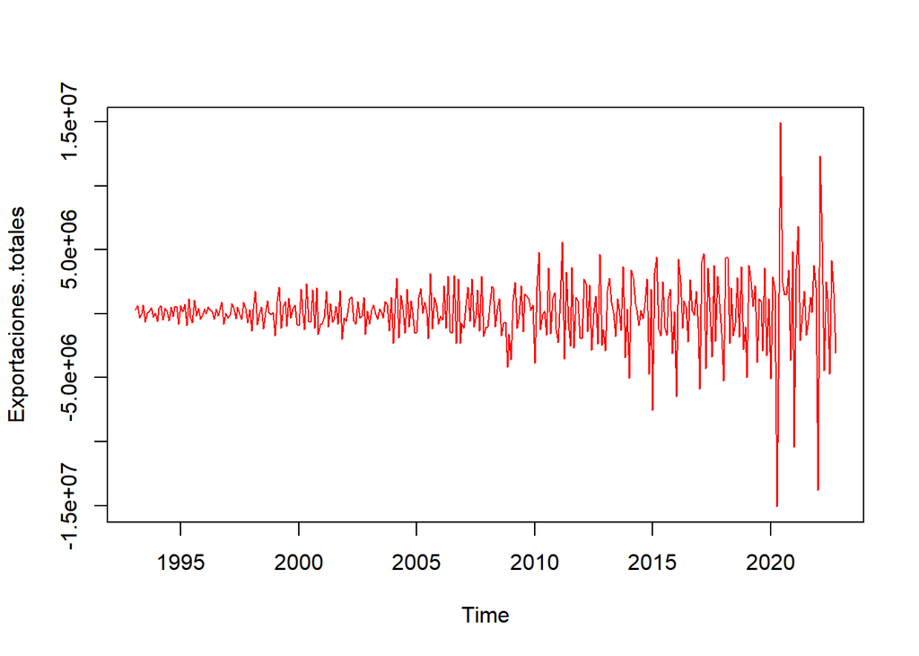

```r
plot(dif1, col="red")
```

#### volvemos a usar la prueba de Dickey-fuller

```r
#prueba para la primera diferncia con logaritmo
adf.test(diflog1, alternative = "stationary")
```

```
##
##  Augmented Dickey-Fuller Test
##
## data:  diflog1
## Dickey-Fuller = -8.3072, Lag order = 7, p-value = 0.01
## alternative hypothesis: stationary
```

```r
#prueba para la primea diferncia sin logaritmo
adf.test(dif1, alternative = "stationary")
```

```
##
##  Augmented Dickey-Fuller Test
##
## data:  dif1
## Dickey-Fuller = -8.8327, Lag order = 7, p-value = 0.01
## alternative hypothesis: stationary
```

en ambas pruebas el p-valor(0.01)<0.05 por lo que concluimos que no existen evidencias suficientes para rechazar la hipotesis alternativa

### Funcion de autocorrelacion y funcion de autocorrelacion parcial

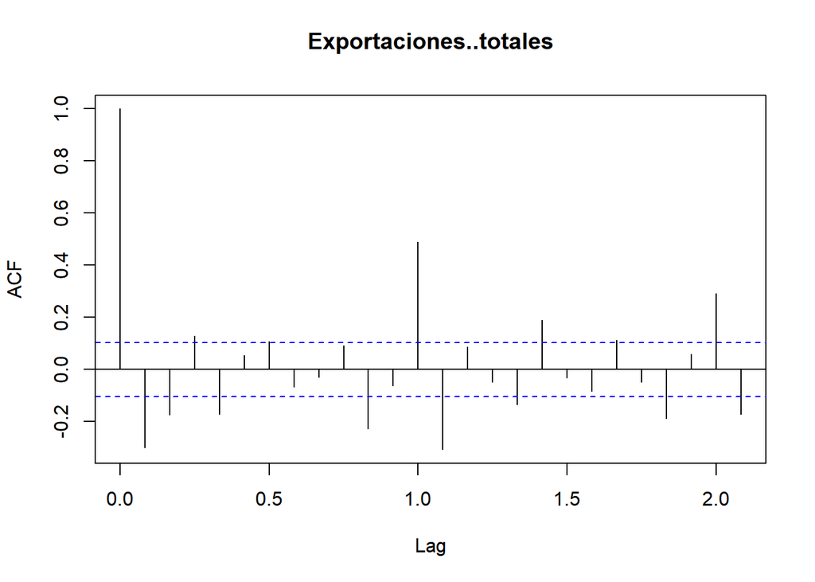

```r
acf(diflog1)
```

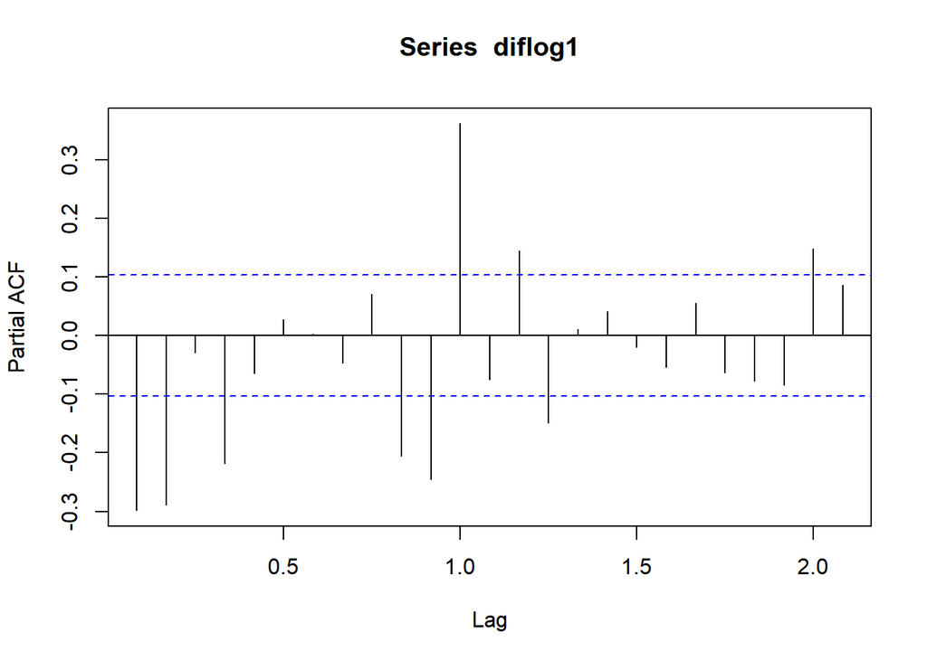

```r
pacf(diflog1)
```

#MODELO

```r
arimar.ts <- arima(time_exportaciones, order = c(2,1,2))
arimar.ts
```

```
##
## Call:
## arima(x = time_exportaciones, order = c(2, 1, 2))
##
## Coefficients:
##           ar1      ar2     ma1      ma2
##       -0.4298  -0.0396  0.0043  -0.3841
## s.e.   0.1394   0.1014  0.1309   0.1069
##
## sigma^2 estimated as 5.449e+12:  log likelihood = -5741.53,  aic = 11493.06
```

```r
arimar1m <- arima(time_exportaciones, order=c(1,1,1))
arimar1m
```

```
##
## Call:
## arima(x = time_exportaciones, order = c(1, 1, 1))
##
## Coefficients:
##          ar1      ma1
##       0.2440  -0.7063
## s.e.  0.0856   0.0603
##
## sigma^2 estimated as 5.584e+12:  log likelihood = -5745.89,  aic = 11497.77
```

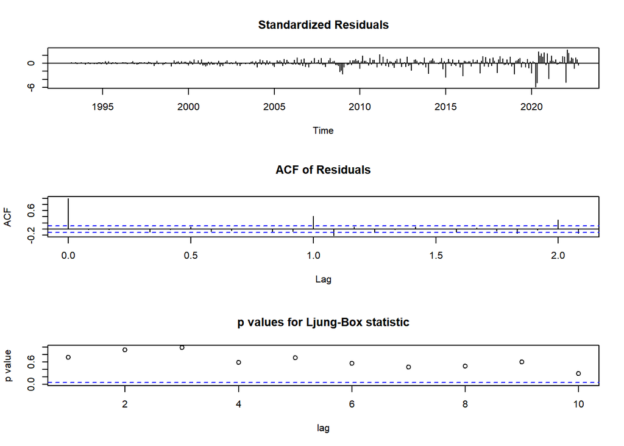

```r
tsdiag(arimar.ts)
```

###diagnostico del modelo 2

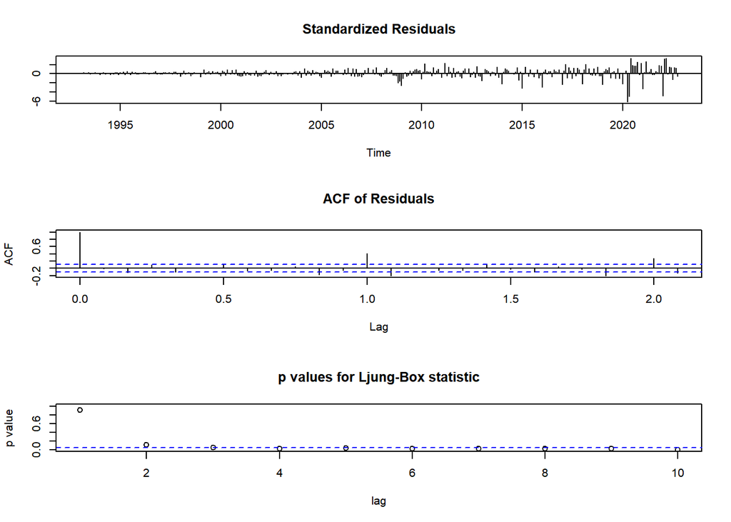

```r
tsdiag(arimar1m)
```

### pruebas de ruido blanco

```r
Box.test(arimar.ts$residuals, type="Ljung-Box")
```

```
##
##  Box-Ljung test
##
## data:  arimar.ts$residuals
## X-squared = 0.12903, df = 1, p-value = 0.7194
```

```r
Box.test(arimar1m$residuals, type="Ljung-Box")
```

```
##
##  Box-Ljung test
##
## data:  arimar1m$residuals
## X-squared = 0.011605, df = 1, p-value = 0.9142
```

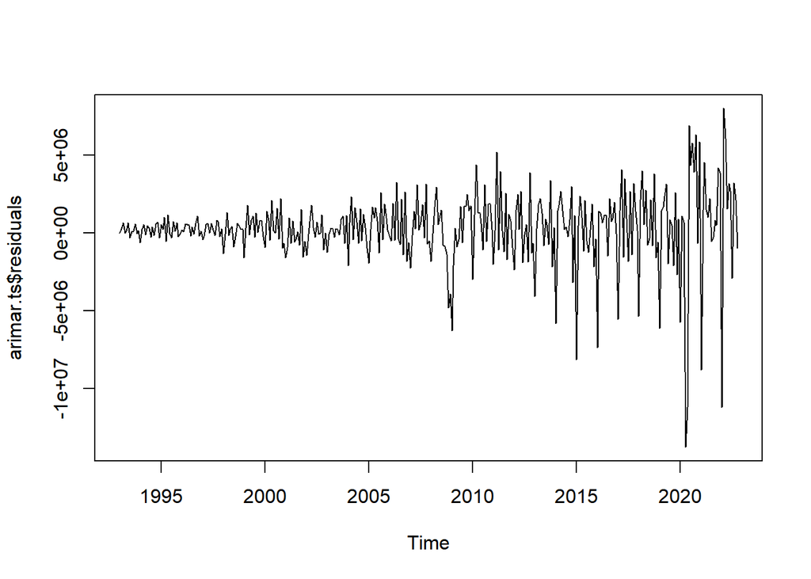

```r
plot(arimar.ts$residuals)
```

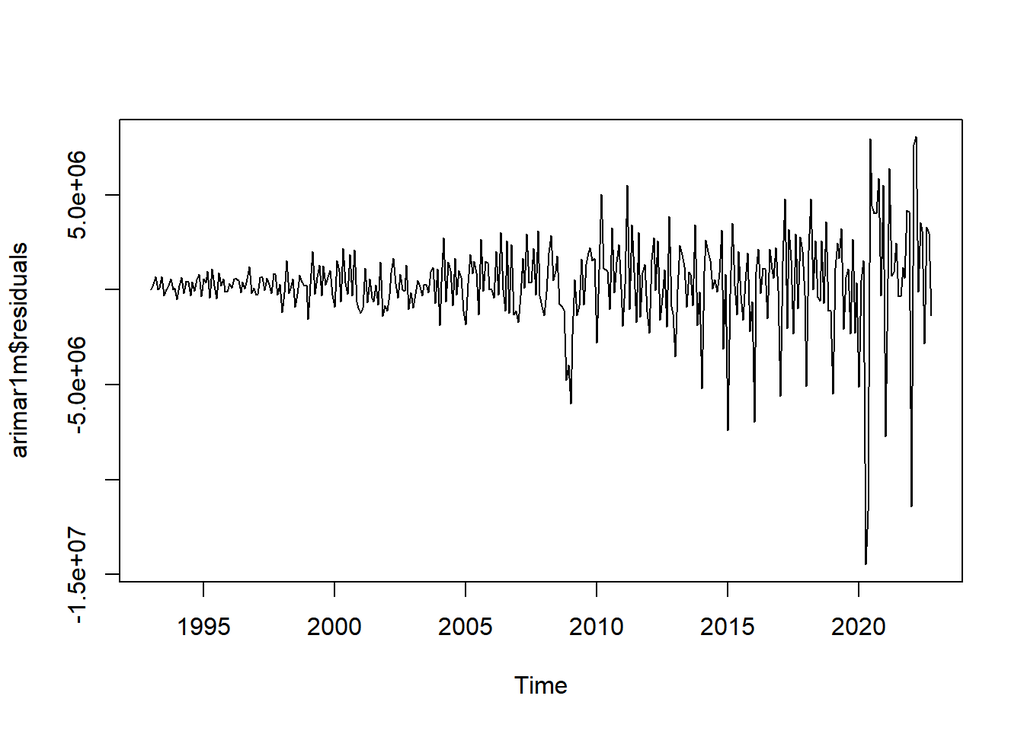

```r
plot(arimar1m$residuals)
```

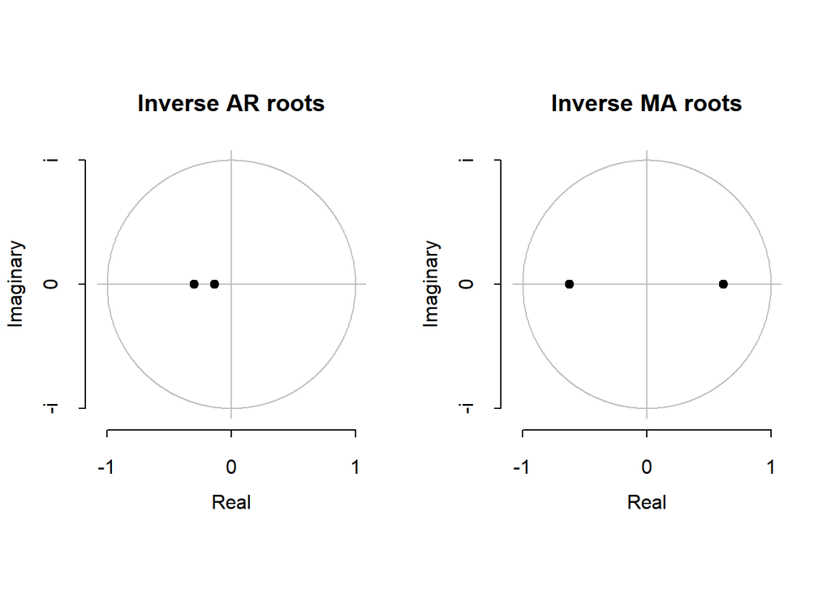

```r
plot(arimar.ts)
```

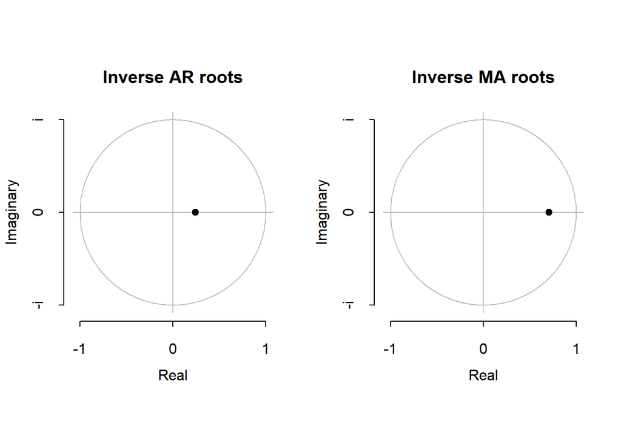

```r
plot(arimar1m)
```

```r
confint(arimar.ts)
```

```
##          2.5 %     97.5 %
## ar1 -0.7031019 -0.1565514
## ar2 -0.2382408  0.1590617
## ma1 -0.2521529  0.2608007
## ma2 -0.5936835 -0.1745951
```

```r
arimar.ts
```

```
##
## Call:
## arima(x = time_exportaciones, order = c(2, 1, 2))
##
## Coefficients:
##           ar1      ar2     ma1      ma2
##       -0.4298  -0.0396  0.0043  -0.3841
## s.e.   0.1394   0.1014  0.1309   0.1069
##
## sigma^2 estimated as 5.449e+12:  log likelihood = -5741.53,  aic = 11493.06
```

```r
confint(arimar1m)
```

```
##           2.5 %     97.5 %
## ar1  0.07626632  0.4117049
## ma1 -0.82455771 -0.5879948
```

```r
arimar1m
```

```
##
## Call:
## arima(x = time_exportaciones, order = c(1, 1, 1))
##
## Coefficients:
##          ar1      ma1
##       0.2440  -0.7063
## s.e.  0.0856   0.0603
##
## sigma^2 estimated as 5.584e+12:  log likelihood = -5745.89,  aic = 11497.77
```

###modelo con autoarima

```r
algorarim <- auto.arima(time_exportaciones)
algorarim
```

```
## Series: time_exportaciones
## ARIMA(4,1,2)(2,0,0)[12]
##
## Coefficients:
##           ar1      ar2      ar3      ar4     ma1     ma2    sar1    sar2
##       -0.4357  -0.7964  -0.1181  -0.3339  0.2122  0.4613  0.4334  0.2573
## s.e.   0.1700   0.1601   0.0797   0.0623  0.1722  0.1541  0.0579  0.0586
##
## sigma^2 = 3.837e+12:  log likelihood = -5678.38
## AIC=11374.76   AICc=11375.28   BIC=11409.66
```

###grafica de los residuos

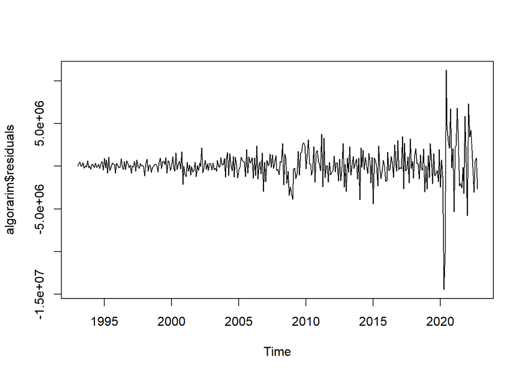

```r
plot(algorarim$residuals)
```

```r
Box.test(algorarim$residuals, type = "Box-Pierce")
```

```
##
##  Box-Pierce test
##
## data:  algorarim$residuals
## X-squared = 0.025899, df = 1, p-value = 0.8721
```

###Grafica del modelo Sarima

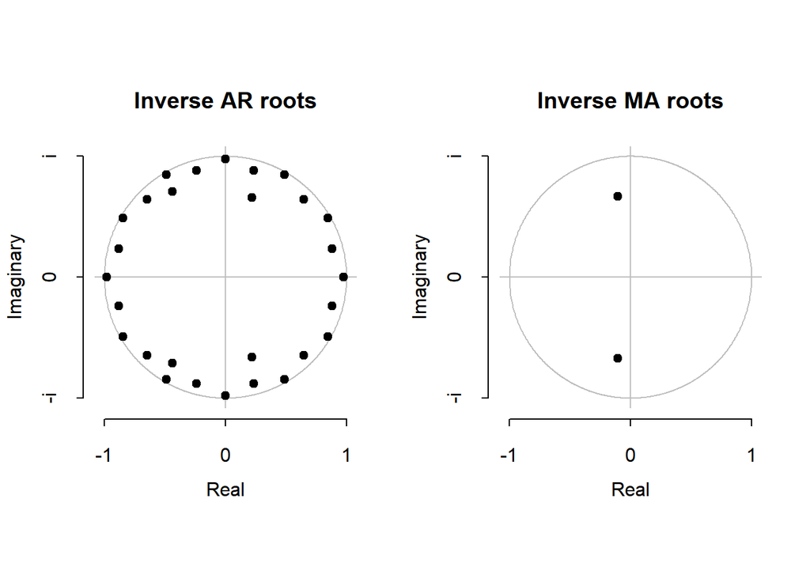

```r
plot(algorarim)
```

```r
arkans <- arima(time_exportaciones, order=c(4,1,4))
arkans
```

```
##
## Call:
## arima(x = time_exportaciones, order = c(4, 1, 4))
##
## Coefficients:
##           ar1      ar2     ar3      ar4     ma1     ma2      ma3      ma4
##       -0.6994  -0.9188  0.0650  -0.2105  0.3388  0.4939  -0.5640  -0.0110
## s.e.   0.2598   0.1723  0.1763   0.1518  0.2617  0.0997   0.1171   0.2182
##
## sigma^2 estimated as 4.699e+12:  log likelihood = -5719.04,  aic = 11456.09
```

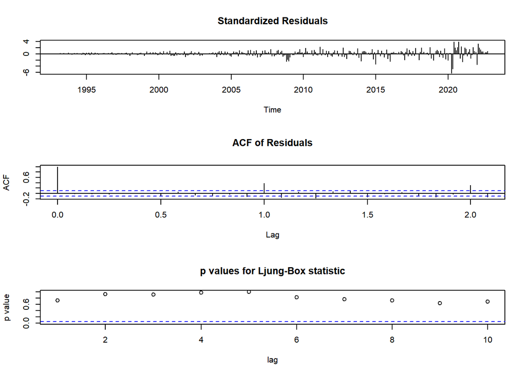

```r
tsdiag(arkans)
```

```r
Box.test(arkans$residuals, type="Ljung-Box")
```

```
##
##  Box-Ljung test
##
## data:  arkans$residuals
## X-squared = 0.12349, df = 1, p-value = 0.7253
```

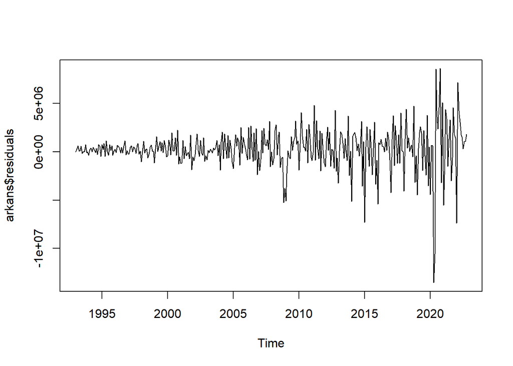

```r
plot(arkans$residuals)
```

```r
mean(arkans$residuals)
```

```
## [1] 288561.2
```

```r
sd(arkans$residuals)
```

```
## [1] 2148340
```